# Prediction of Patient Status using Voice Measurements

INSOFE Lab Assignment on Logistic Regression - Batch 30

8 July 2017

**NOTE** Before starting this assignment please remember to clear your environment, you can do that by running the following code chunk

```r
rm(list = ls(all=T))
```

# Agenda

- Get the data
- Data Pre-processing
- Build a model
- Predictions
- Communication

# Reading & Understanding the Data

- The “parkinsons_data.csv”" dataset is composed of a range of biomedical voice measurements. Each column in the table is a particular voice measure, and each row corresponds one of 195 voice recordings.
- The dataset has 195 rows and 23 columns.
- The column/variable names’ explanation is given below:
1. **MDVP:Fo(Hz) :** Average vocal fundamental frequency
2. **MDVP:Fhi(Hz) :** Maximum vocal fundamental frequency
3. **MDVP:Flo(Hz) :** Minimum vocal fundamental frequency
4. **MDVP:Jitter(%); MDVP:Jitter(Abs); MDVP:RAP; MDVP:PPQ; Jitter:DDP :**_ Several measures of variation in fundamental frequency
5. **MDVP:Shimmer; MDVP:Shimmer(dB); Shimmer:APQ3; Shimmer:APQ5; MDVP:APQ; Shimmer:DDA :** Several measures of variation in amplitude
6. **NHR; HNR :** Two measures of ratio of noise to tonal components in the voice
7. **status :** Health status of the subject (Parkinson’s) - Positive, (Normal) - Healthy
8. **RPDE; D2 :** Two nonlinear dynamical complexity measures
9. **DFA :** Signal fractal scaling exponent
10. **spread1; spread2; PPE :** Three nonlinear measures of fundamental frequency variation
- Make sure the dataset is located in your current working directory and read in the data

```r
getwd()
```

```
## [1] "G:/Logistic"
```

```r
setwd("G:/Logistic")

read.csv("parkinsons_data.csv")->df

df
```

[output not shown]

[output cut: 769 more lines]

```r
names(df)
```

```
##  [1] "MDVP.Fo.Hz."      "MDVP.Fhi.Hz."     "MDVP.Flo.Hz."
##  [4] "MDVP.Jitter..."   "MDVP.Jitter.Abs." "MDVP.RAP"
##  [7] "MDVP.PPQ"         "Jitter.DDP"       "MDVP.Shimmer"
## [10] "MDVP.Shimmer.dB." "Shimmer.APQ3"     "Shimmer.APQ5"
## [13] "MDVP.APQ"         "Shimmer.DDA"      "NHR"
## [16] "HNR"              "status"           "RPDE"
## [19] "DFA"              "spread1"          "spread2"
## [22] "D2"               "PPE"
```

```r
dim(df)
```

```
## [1] 195  23
```

- Use the str() function to get a feel for the dataset.

```r
str(df)
```

```
## 'data.frame':    195 obs. of  23 variables:
##  $ MDVP.Fo.Hz.     : num  120 122 117 117 116 ...
##  $ MDVP.Fhi.Hz.    : num  157 149 131 138 142 ...
##  $ MDVP.Flo.Hz.    : num  75 114 112 111 111 ...
##  $ MDVP.Jitter...  : num  0.00784 0.00968 0.0105 0.00997 0.01284 ...
##  $ MDVP.Jitter.Abs.: num  0.00007 0.00008 0.00009 0.00009 0.00011 0.00008 0.00003 0.00003 0.00006 0.00006 ...
##  $ MDVP.RAP        : num  0.0037 0.00465 0.00544 0.00502 0.00655 0.00463 0.00155 0.00144 0.00293 0.00268 ...
##  $ MDVP.PPQ        : num  0.00554 0.00696 0.00781 0.00698 0.00908 0.0075 0.00202 0.00182 0.00332 0.00332 ...
##  $ Jitter.DDP      : num  0.0111 0.0139 0.0163 0.015 0.0197 ...
##  $ MDVP.Shimmer    : num  0.0437 0.0613 0.0523 0.0549 0.0643 ...
##  $ MDVP.Shimmer.dB.: num  0.426 0.626 0.482 0.517 0.584 0.456 0.14 0.134 0.191 0.255 ...
##  $ Shimmer.APQ3    : num  0.0218 0.0313 0.0276 0.0292 0.0349 ...
##  $ Shimmer.APQ5    : num  0.0313 0.0452 0.0386 0.0401 0.0483 ...
##  $ MDVP.APQ        : num  0.0297 0.0437 0.0359 0.0377 0.0447 ...
##  $ Shimmer.DDA     : num  0.0654 0.094 0.0827 0.0877 0.1047 ...
##  $ NHR             : num  0.0221 0.0193 0.0131 0.0135 0.0177 ...
##  $ HNR             : num  21 19.1 20.7 20.6 19.6 ...
##  $ status          : Factor w/ 2 levels "Normal","Parkinson's": 2 2 2 2 2 2 2 2 2 2 ...
##  $ RPDE            : num  0.415 0.458 0.43 0.435 0.417 ...
##  $ DFA             : num  0.815 0.82 0.825 0.819 0.823 ...
##  $ spread1         : num  -4.81 -4.08 -4.44 -4.12 -3.75 ...
##  $ spread2         : num  0.266 0.336 0.311 0.334 0.235 ...
##  $ D2              : num  2.3 2.49 2.34 2.41 2.33 ...
##  $ PPE             : num  0.285 0.369 0.333 0.369 0.41 ...
```

- Take a look at the data using the “head()” and “tail()” functions

```r
head(df)
```

```
##   MDVP.Fo.Hz. MDVP.Fhi.Hz. MDVP.Flo.Hz. MDVP.Jitter... MDVP.Jitter.Abs.
## 1     119.992      157.302       74.997        0.00784          0.00007
## 2     122.400      148.650      113.819        0.00968          0.00008
## 3     116.682      131.111      111.555        0.01050          0.00009
## 4     116.676      137.871      111.366        0.00997          0.00009
## 5     116.014      141.781      110.655        0.01284          0.00011
## 6     120.552      131.162      113.787        0.00968          0.00008
##   MDVP.RAP MDVP.PPQ Jitter.DDP MDVP.Shimmer MDVP.Shimmer.dB. Shimmer.APQ3
## 1  0.00370  0.00554    0.01109      0.04374            0.426      0.02182
## 2  0.00465  0.00696    0.01394      0.06134            0.626      0.03134
## 3  0.00544  0.00781    0.01633      0.05233            0.482      0.02757
## 4  0.00502  0.00698    0.01505      0.05492            0.517      0.02924
## 5  0.00655  0.00908    0.01966      0.06425            0.584      0.03490
## 6  0.00463  0.00750    0.01388      0.04701            0.456      0.02328
##   Shimmer.APQ5 MDVP.APQ Shimmer.DDA     NHR    HNR      status     RPDE
## 1      0.03130  0.02971     0.06545 0.02211 21.033 Parkinson's 0.414783
## 2      0.04518  0.04368     0.09403 0.01929 19.085 Parkinson's 0.458359
## 3      0.03858  0.03590     0.08270 0.01309 20.651 Parkinson's 0.429895
## 4      0.04005  0.03772     0.08771 0.01353 20.644 Parkinson's 0.434969
## 5      0.04825  0.04465     0.10470 0.01767 19.649 Parkinson's 0.417356
## 6      0.03526  0.03243     0.06985 0.01222 21.378 Parkinson's 0.415564
##        DFA   spread1  spread2       D2      PPE
## 1 0.815285 -4.813031 0.266482 2.301442 0.284654
## 2 0.819521 -4.075192 0.335590 2.486855 0.368674
## 3 0.825288 -4.443179 0.311173 2.342259 0.332634
## 4 0.819235 -4.117501 0.334147 2.405554 0.368975
## 5 0.823484 -3.747787 0.234513 2.332180 0.410335
## 6 0.825069 -4.242867 0.299111 2.187560 0.357775
```

```r
tail(df)
```

```
##     MDVP.Fo.Hz. MDVP.Fhi.Hz. MDVP.Flo.Hz. MDVP.Jitter... MDVP.Jitter.Abs.
## 190     201.774      262.707       78.228        0.00694            3e-05
## 191     174.188      230.978       94.261        0.00459            3e-05
## 192     209.516      253.017       89.488        0.00564            3e-05
## 193     174.688      240.005       74.287        0.01360            8e-05
## 194     198.764      396.961       74.904        0.00740            4e-05
## 195     214.289      260.277       77.973        0.00567            3e-05
##     MDVP.RAP MDVP.PPQ Jitter.DDP MDVP.Shimmer MDVP.Shimmer.dB.
## 190  0.00412  0.00396    0.01235      0.02574            0.255
## 191  0.00263  0.00259    0.00790      0.04087            0.405
## 192  0.00331  0.00292    0.00994      0.02751            0.263
## 193  0.00624  0.00564    0.01873      0.02308            0.256
## 194  0.00370  0.00390    0.01109      0.02296            0.241
## 195  0.00295  0.00317    0.00885      0.01884            0.190
##     Shimmer.APQ3 Shimmer.APQ5 MDVP.APQ Shimmer.DDA     NHR    HNR status
## 190      0.01454      0.01582  0.01758     0.04363 0.04441 19.368 Normal
## 191      0.02336      0.02498  0.02745     0.07008 0.02764 19.517 Normal
## 192      0.01604      0.01657  0.01879     0.04812 0.01810 19.147 Normal
## 193      0.01268      0.01365  0.01667     0.03804 0.10715 17.883 Normal
## 194      0.01265      0.01321  0.01588     0.03794 0.07223 19.020 Normal
## 195      0.01026      0.01161  0.01373     0.03078 0.04398 21.209 Normal
##         RPDE      DFA   spread1  spread2       D2      PPE
## 190 0.508479 0.683761 -6.934474 0.159890 2.316346 0.112838
## 191 0.448439 0.657899 -6.538586 0.121952 2.657476 0.133050
## 192 0.431674 0.683244 -6.195325 0.129303 2.784312 0.168895
## 193 0.407567 0.655683 -6.787197 0.158453 2.679772 0.131728
## 194 0.451221 0.643956 -6.744577 0.207454 2.138608 0.123306
## 195 0.462803 0.664357 -5.724056 0.190667 2.555477 0.148569
```

- Are there any missing values in the dataset?

```r
sum(is.na(df))
```

```
## [1] 0
```

# Data Pre-processing

## Train/Test Split

```r
set.seed(420)

train_rows <- sample(1:nrow(df), 0.7*nrow(df))

train_data <- df[train_rows, ]

test_data <- df[-train_rows, ]
summary(train_data)
```

```
##   MDVP.Fo.Hz.      MDVP.Fhi.Hz.    MDVP.Flo.Hz.    MDVP.Jitter...
##  Min.   : 88.33   Min.   :102.3   Min.   : 65.75   Min.   :0.001740
##  1st Qu.:116.87   1st Qu.:134.0   1st Qu.: 85.18   1st Qu.:0.003450
##  Median :148.21   Median :178.2   Median :101.82   Median :0.004955
##  Mean   :154.05   Mean   :196.2   Mean   :115.72   Mean   :0.006525
##  3rd Qu.:187.95   3rd Qu.:221.2   3rd Qu.:136.03   3rd Qu.:0.007432
##  Max.   :245.51   Max.   :586.6   Max.   :239.17   Max.   :0.033160
##  MDVP.Jitter.Abs.       MDVP.RAP           MDVP.PPQ
##  Min.   :9.000e-06   Min.   :0.000750   Min.   :0.000960
##  1st Qu.:2.000e-05   1st Qu.:0.001660   1st Qu.:0.001895
##  Median :3.000e-05   Median :0.002500   Median :0.002775
##  Mean   :4.614e-05   Mean   :0.003508   Mean   :0.003597
##  3rd Qu.:6.000e-05   3rd Qu.:0.003747   3rd Qu.:0.003965
##  Max.   :2.600e-04   Max.   :0.021440   Max.   :0.019580
##    Jitter.DDP        MDVP.Shimmer     MDVP.Shimmer.dB.  Shimmer.APQ3
##  Min.   :0.002250   Min.   :0.00954   Min.   :0.0850   Min.   :0.004550
##  1st Qu.:0.004987   1st Qu.:0.01552   1st Qu.:0.1378   1st Qu.:0.007712
##  Median :0.007500   Median :0.02289   Median :0.2185   Median :0.012665
##  Mean   :0.010526   Mean   :0.02982   Mean   :0.2852   Mean   :0.015736
##  3rd Qu.:0.011250   3rd Qu.:0.03761   3rd Qu.:0.3500   3rd Qu.:0.019060
##  Max.   :0.064330   Max.   :0.11908   Max.   :1.3020   Max.   :0.056470
##   Shimmer.APQ5         MDVP.APQ        Shimmer.DDA           NHR
##  Min.   :0.005700   Min.   :0.00719   Min.   :0.01364   Min.   :0.000650
##  1st Qu.:0.009328   1st Qu.:0.01261   1st Qu.:0.02314   1st Qu.:0.006085
##  Median :0.013425   Median :0.01798   Median :0.03799   Median :0.011635
##  Mean   :0.017853   Mean   :0.02413   Mean   :0.04721   Mean   :0.027390
##  3rd Qu.:0.022345   3rd Qu.:0.02920   3rd Qu.:0.05718   3rd Qu.:0.026295
##  Max.   :0.079400   Max.   :0.13778   Max.   :0.16942   Max.   :0.314820
##       HNR                 status         RPDE             DFA
##  Min.   : 8.441   Normal     : 31   Min.   :0.2566   Min.   :0.5743
##  1st Qu.:19.131   Parkinson's:105   1st Qu.:0.4218   1st Qu.:0.6735
##  Median :22.232                     Median :0.4886   Median :0.7223
##  Mean   :21.948                     Mean   :0.4966   Mean   :0.7166
##  3rd Qu.:25.240                     3rd Qu.:0.5834   3rd Qu.:0.7616
##  Max.   :33.047                     Max.   :0.6852   Max.   :0.8235
##     spread1          spread2               D2             PPE
##  Min.   :-7.965   Min.   :0.006274   Min.   :1.423   Min.   :0.04454
##  1st Qu.:-6.413   1st Qu.:0.177242   1st Qu.:2.115   1st Qu.:0.14195
##  Median :-5.686   Median :0.221301   Median :2.408   Median :0.20016
##  Mean   :-5.658   Mean   :0.228951   Mean   :2.398   Mean   :0.20804
##  3rd Qu.:-5.058   3rd Qu.:0.279973   3rd Qu.:2.642   3rd Qu.:0.25030
##  Max.   :-2.434   Max.   :0.450493   Max.   :3.275   Max.   :0.52737
```

```r
summary(test_data)
```

```
##   MDVP.Fo.Hz.      MDVP.Fhi.Hz.    MDVP.Flo.Hz.    MDVP.Jitter...
##  Min.   : 95.39   Min.   :102.1   Min.   : 65.48   Min.   :0.001680
##  1st Qu.:120.95   1st Qu.:138.0   1st Qu.: 83.64   1st Qu.:0.003495
##  Median :149.82   Median :166.6   Median :107.32   Median :0.004800
##  Mean   :154.64   Mean   :199.2   Mean   :117.71   Mean   :0.005519
##  3rd Qu.:172.14   3rd Qu.:226.7   3rd Qu.:143.07   3rd Qu.:0.006940
##  Max.   :260.11   Max.   :592.0   Max.   :237.30   Max.   :0.015680
##  MDVP.Jitter.Abs.       MDVP.RAP           MDVP.PPQ
##  Min.   :7.000e-06   Min.   :0.000680   Min.   :0.000920
##  1st Qu.:2.000e-05   1st Qu.:0.001670   1st Qu.:0.001790
##  Median :3.000e-05   Median :0.002320   Median :0.002670
##  Mean   :3.893e-05   Mean   :0.002841   Mean   :0.003098
##  3rd Qu.:5.000e-05   3rd Qu.:0.003875   3rd Qu.:0.003900
##  Max.   :1.000e-04   Max.   :0.008630   Max.   :0.009460
##    Jitter.DDP        MDVP.Shimmer     MDVP.Shimmer.dB.  Shimmer.APQ3
##  Min.   :0.002040   Min.   :0.01022   Min.   :0.0900   Min.   :0.00476
##  1st Qu.:0.005015   1st Qu.:0.01837   1st Qu.:0.1645   1st Qu.:0.00944
##  Median :0.006960   Median :0.02442   Median :0.2240   Median :0.01323
##  Mean   :0.008524   Mean   :0.02945   Mean   :0.2754   Mean   :0.01550
##  3rd Qu.:0.011625   3rd Qu.:0.03848   3rd Qu.:0.3530   3rd Qu.:0.02038
##  Max.   :0.025890   Max.   :0.08143   Max.   :0.8210   Max.   :0.03804
##   Shimmer.APQ5        MDVP.APQ        Shimmer.DDA           NHR
##  Min.   :0.00588   Min.   :0.00860   Min.   :0.01428   Min.   :0.00231
##  1st Qu.:0.01050   1st Qu.:0.01384   1st Qu.:0.02831   1st Qu.:0.00584
##  Median :0.01399   Median :0.01949   Median :0.03969   Median :0.01211
##  Mean   :0.01794   Mean   :0.02396   Mean   :0.04649   Mean   :0.01898
##  3rd Qu.:0.02278   3rd Qu.:0.03018   3rd Qu.:0.06114   3rd Qu.:0.02252
##  Max.   :0.05426   Max.   :0.08808   Max.   :0.11411   Max.   :0.08725
##       HNR                status        RPDE             DFA
##  Min.   :11.74   Normal     :17   Min.   :0.3051   Min.   :0.6281
##  1st Qu.:19.50   Parkinson's:42   1st Qu.:0.4227   1st Qu.:0.6771
##  Median :21.81                    Median :0.4989   Median :0.7221
##  Mean   :21.74                    Mean   :0.5030   Mean   :0.7215
##  3rd Qu.:24.82                    3rd Qu.:0.6049   3rd Qu.:0.7618
##  Max.   :29.75                    Max.   :0.6771   Max.   :0.8253
##     spread1          spread2             D2             PPE
##  Min.   :-7.518   Min.   :0.0733   Min.   :1.821   Min.   :0.07559
##  1st Qu.:-6.593   1st Qu.:0.1596   1st Qu.:2.067   1st Qu.:0.12474
##  Median :-5.825   Median :0.2103   Median :2.266   Median :0.18499
##  Mean   :-5.745   Mean   :0.2209   Mean   :2.344   Mean   :0.20311
##  3rd Qu.:-4.996   3rd Qu.:0.2651   3rd Qu.:2.501   3rd Qu.:0.25989
##  Max.   :-3.298   Max.   :0.4148   Max.   :3.671   Max.   :0.45753
```

# Build a model

## Basic Logistic Regression Model

- Use the glm() function to build a basic model
- Build a model using all the variables, excluding the response variable, in the dataset

```r
glm(status~.,data = train_data,family = "binomial")->log_mod
log_mod
```

```
##
## Call:  glm(formula = status ~ ., family = "binomial", data = train_data)
##
## Coefficients:
##      (Intercept)       MDVP.Fo.Hz.      MDVP.Fhi.Hz.      MDVP.Flo.Hz.
##        1.610e+01        -1.585e-02        -1.060e-02         6.340e-03
##   MDVP.Jitter...  MDVP.Jitter.Abs.          MDVP.RAP          MDVP.PPQ
##       -1.546e+03        -3.597e+04         7.378e+04        -1.069e+03
##       Jitter.DDP      MDVP.Shimmer  MDVP.Shimmer.dB.      Shimmer.APQ3
##       -2.353e+04         4.862e+02         7.250e+01        -4.415e+04
##     Shimmer.APQ5          MDVP.APQ       Shimmer.DDA               NHR
##       -6.236e+02         3.144e+01         1.437e+04        -4.052e+01
##              HNR              RPDE               DFA           spread1
##        1.076e-01        -2.984e+00        -5.236e+00         2.536e+00
##          spread2                D2               PPE
##        6.326e+00         2.000e+00         7.846e-01
##
## Degrees of Freedom: 135 Total (i.e. Null);  113 Residual
## Null Deviance:       146
## Residual Deviance: 61.01     AIC: 107
```

```r
summary(log_mod)
```

```
##
## Call:
## glm(formula = status ~ ., family = "binomial", data = train_data)
##
## Deviance Residuals:
##      Min        1Q    Median        3Q       Max
## -2.07157   0.00002   0.05899   0.39201   1.61897
##
## Coefficients:
##                    Estimate Std. Error z value Pr(>|z|)
## (Intercept)       1.610e+01  2.484e+01   0.648    0.517
## MDVP.Fo.Hz.      -1.585e-02  2.812e-02  -0.564    0.573
## MDVP.Fhi.Hz.     -1.060e-02  9.761e-03  -1.086    0.278
## MDVP.Flo.Hz.      6.340e-03  1.480e-02   0.428    0.668
## MDVP.Jitter...   -1.546e+03  1.700e+03  -0.910    0.363
## MDVP.Jitter.Abs. -3.597e+04  1.257e+05  -0.286    0.775
## MDVP.RAP          7.378e+04  1.649e+05   0.447    0.655
## MDVP.PPQ         -1.069e+03  2.161e+03  -0.495    0.621
## Jitter.DDP       -2.353e+04  5.501e+04  -0.428    0.669
## MDVP.Shimmer      4.862e+02  1.459e+03   0.333    0.739
## MDVP.Shimmer.dB.  7.250e+01  5.591e+01   1.297    0.195
## Shimmer.APQ3     -4.415e+04  1.460e+05  -0.302    0.762
## Shimmer.APQ5     -6.236e+02  5.754e+02  -1.084    0.279
## MDVP.APQ          3.144e+01  6.221e+02   0.051    0.960
## Shimmer.DDA       1.437e+04  4.878e+04   0.295    0.768
## NHR              -4.052e+01  6.342e+01  -0.639    0.523
## HNR               1.076e-01  2.656e-01   0.405    0.685
## RPDE             -2.984e+00  6.025e+00  -0.495    0.620
## DFA              -5.236e+00  1.182e+01  -0.443    0.658
## spread1           2.536e+00  2.676e+00   0.947    0.343
## spread2           6.326e+00  8.174e+00   0.774    0.439
## D2                2.000e+00  1.753e+00   1.141    0.254
## PPE               7.846e-01  3.721e+01   0.021    0.983
##
## (Dispersion parameter for binomial family taken to be 1)
##
##     Null deviance: 146.003  on 135  degrees of freedom
## Residual deviance:  61.014  on 113  degrees of freedom
## AIC: 107.01
##
## Number of Fisher Scoring iterations: 9
```

- Get the summary of the model and understand the output

```r
summary(log_mod)
```

```
##
## Call:
## glm(formula = status ~ ., family = "binomial", data = train_data)
##
## Deviance Residuals:
##      Min        1Q    Median        3Q       Max
## -2.07157   0.00002   0.05899   0.39201   1.61897
##
## Coefficients:
##                    Estimate Std. Error z value Pr(>|z|)
## (Intercept)       1.610e+01  2.484e+01   0.648    0.517
## MDVP.Fo.Hz.      -1.585e-02  2.812e-02  -0.564    0.573
## MDVP.Fhi.Hz.     -1.060e-02  9.761e-03  -1.086    0.278
## MDVP.Flo.Hz.      6.340e-03  1.480e-02   0.428    0.668
## MDVP.Jitter...   -1.546e+03  1.700e+03  -0.910    0.363
## MDVP.Jitter.Abs. -3.597e+04  1.257e+05  -0.286    0.775
## MDVP.RAP          7.378e+04  1.649e+05   0.447    0.655
## MDVP.PPQ         -1.069e+03  2.161e+03  -0.495    0.621
## Jitter.DDP       -2.353e+04  5.501e+04  -0.428    0.669
## MDVP.Shimmer      4.862e+02  1.459e+03   0.333    0.739
## MDVP.Shimmer.dB.  7.250e+01  5.591e+01   1.297    0.195
## Shimmer.APQ3     -4.415e+04  1.460e+05  -0.302    0.762
## Shimmer.APQ5     -6.236e+02  5.754e+02  -1.084    0.279
## MDVP.APQ          3.144e+01  6.221e+02   0.051    0.960
## Shimmer.DDA       1.437e+04  4.878e+04   0.295    0.768
## NHR              -4.052e+01  6.342e+01  -0.639    0.523
## HNR               1.076e-01  2.656e-01   0.405    0.685
## RPDE             -2.984e+00  6.025e+00  -0.495    0.620
## DFA              -5.236e+00  1.182e+01  -0.443    0.658
## spread1           2.536e+00  2.676e+00   0.947    0.343
## spread2           6.326e+00  8.174e+00   0.774    0.439
## D2                2.000e+00  1.753e+00   1.141    0.254
## PPE               7.846e-01  3.721e+01   0.021    0.983
##
## (Dispersion parameter for binomial family taken to be 1)
##
##     Null deviance: 146.003  on 135  degrees of freedom
## Residual deviance:  61.014  on 113  degrees of freedom
## AIC: 107.01
##
## Number of Fisher Scoring iterations: 9
```

## Create an ROC Curve

```r
library(MASS)

#stepAIC(log_mod,direction = "both")->log_step

stepAIC(log_mod)->log_step
```

```
## Start:  AIC=107.01
## status ~ MDVP.Fo.Hz. + MDVP.Fhi.Hz. + MDVP.Flo.Hz. + MDVP.Jitter... +
##     MDVP.Jitter.Abs. + MDVP.RAP + MDVP.PPQ + Jitter.DDP + MDVP.Shimmer +
##     MDVP.Shimmer.dB. + Shimmer.APQ3 + Shimmer.APQ5 + MDVP.APQ +
##     Shimmer.DDA + NHR + HNR + RPDE + DFA + spread1 + spread2 +
##     D2 + PPE
```

[output not shown]

```
##                    Df Deviance    AIC
## - PPE               1   61.015 105.02
## - MDVP.APQ          1   61.017 105.02
## - MDVP.Jitter.Abs.  1   61.095 105.09
## - Shimmer.DDA       1   61.101 105.10
## - Shimmer.APQ3      1   61.106 105.11
## - MDVP.Shimmer      1   61.126 105.13
## - HNR               1   61.182 105.18
## - Jitter.DDP        1   61.199 105.20
## - MDVP.Flo.Hz.      1   61.201 105.20
## - DFA               1   61.214 105.21
## - MDVP.RAP          1   61.217 105.22
## - RPDE              1   61.258 105.26
## - MDVP.PPQ          1   61.262 105.26
## - MDVP.Fo.Hz.       1   61.330 105.33
## - NHR               1   61.350 105.35
## - spread2           1   61.646 105.65
## - spread1           1   61.938 105.94
## - MDVP.Jitter...    1   61.943 105.94
## - Shimmer.APQ5      1   62.162 106.16
## - D2                1   62.402 106.40
## - MDVP.Fhi.Hz.      1   62.954 106.95
## - MDVP.Shimmer.dB.  1   62.987 106.99
## <none>                  61.014 107.01
```

```
##
## Step:  AIC=105.01
## status ~ MDVP.Fo.Hz. + MDVP.Fhi.Hz. + MDVP.Flo.Hz. + MDVP.Jitter... +
##     MDVP.Jitter.Abs. + MDVP.RAP + MDVP.PPQ + Jitter.DDP + MDVP.Shimmer +
##     MDVP.Shimmer.dB. + Shimmer.APQ3 + Shimmer.APQ5 + MDVP.APQ +
##     Shimmer.DDA + NHR + HNR + RPDE + DFA + spread1 + spread2 +
##     D2
```

```
##                    Df Deviance    AIC
## - MDVP.APQ          1   61.018 103.02
## - MDVP.Jitter.Abs.  1   61.099 103.10
## - Shimmer.DDA       1   61.105 103.11
## - Shimmer.APQ3      1   61.110 103.11
## - MDVP.Shimmer      1   61.127 103.13
## - HNR               1   61.183 103.18
## - Jitter.DDP        1   61.199 103.20
## - MDVP.Flo.Hz.      1   61.202 103.20
## - DFA               1   61.214 103.21
## - MDVP.RAP          1   61.217 103.22
## - RPDE              1   61.262 103.26
## - MDVP.PPQ          1   61.276 103.28
## - MDVP.Fo.Hz.       1   61.333 103.33
## - NHR               1   61.457 103.46
## - spread2           1   61.646 103.65
## - MDVP.Jitter...    1   61.992 103.99
## - Shimmer.APQ5      1   62.183 104.18
## - D2                1   62.403 104.40
## - MDVP.Fhi.Hz.      1   62.955 104.95
## - MDVP.Shimmer.dB.  1   62.993 104.99
## <none>                  61.015 105.02
## - spread1           1   65.461 107.46
```

```
##
## Step:  AIC=103.02
## status ~ MDVP.Fo.Hz. + MDVP.Fhi.Hz. + MDVP.Flo.Hz. + MDVP.Jitter... +
##     MDVP.Jitter.Abs. + MDVP.RAP + MDVP.PPQ + Jitter.DDP + MDVP.Shimmer +
##     MDVP.Shimmer.dB. + Shimmer.APQ3 + Shimmer.APQ5 + Shimmer.DDA +
##     NHR + HNR + RPDE + DFA + spread1 + spread2 + D2
```

```
##                    Df Deviance    AIC
## - Shimmer.DDA       1   61.105 101.11
## - Shimmer.APQ3      1   61.110 101.11
## - MDVP.Jitter.Abs.  1   61.120 101.12
## - HNR               1   61.183 101.18
## - Jitter.DDP        1   61.211 101.21
## - DFA               1   61.216 101.22
## - MDVP.RAP          1   61.229 101.23
## - MDVP.Flo.Hz.      1   61.230 101.23
## - RPDE              1   61.265 101.27
## - MDVP.PPQ          1   61.316 101.32
## - MDVP.Fo.Hz.       1   61.345 101.34
## - NHR               1   61.478 101.48
## - MDVP.Shimmer      1   61.519 101.52
## - spread2           1   61.663 101.66
## - MDVP.Jitter...    1   62.111 102.11
## - Shimmer.APQ5      1   62.288 102.29
## - D2                1   62.423 102.42
## <none>                  61.018 103.02
## - MDVP.Shimmer.dB.  1   63.037 103.04
## - MDVP.Fhi.Hz.      1   63.127 103.13
## - spread1           1   66.313 106.31
```

```
##
## Step:  AIC=101.11
## status ~ MDVP.Fo.Hz. + MDVP.Fhi.Hz. + MDVP.Flo.Hz. + MDVP.Jitter... +
##     MDVP.Jitter.Abs. + MDVP.RAP + MDVP.PPQ + Jitter.DDP + MDVP.Shimmer +
##     MDVP.Shimmer.dB. + Shimmer.APQ3 + Shimmer.APQ5 + NHR + HNR +
##     RPDE + DFA + spread1 + spread2 + D2
```

```
##                    Df Deviance     AIC
## - MDVP.Jitter.Abs.  1   61.196  99.196
## - HNR               1   61.229  99.229
## - DFA               1   61.285  99.285
## - Jitter.DDP        1   61.319  99.319
## - MDVP.RAP          1   61.337  99.337
## - RPDE              1   61.343  99.343
## - MDVP.Flo.Hz.      1   61.371  99.371
## - MDVP.Fo.Hz.       1   61.428  99.428
## - MDVP.PPQ          1   61.433  99.433
## - NHR               1   61.548  99.548
## - MDVP.Shimmer      1   61.595  99.595
## - spread2           1   61.696  99.696
## - MDVP.Jitter...    1   62.130 100.130
## - Shimmer.APQ5      1   62.343 100.343
## - D2                1   62.463 100.463
## <none>                  61.105 101.105
## - MDVP.Shimmer.dB.  1   63.149 101.149
## - MDVP.Fhi.Hz.      1   63.469 101.469
## - Shimmer.APQ3      1   63.856 101.856
## - spread1           1   66.316 104.316
##
## Step:  AIC=99.2
## status ~ MDVP.Fo.Hz. + MDVP.Fhi.Hz. + MDVP.Flo.Hz. + MDVP.Jitter... +
##     MDVP.RAP + MDVP.PPQ + Jitter.DDP + MDVP.Shimmer + MDVP.Shimmer.dB. +
##     Shimmer.APQ3 + Shimmer.APQ5 + NHR + HNR + RPDE + DFA + spread1 +
##     spread2 + D2
```

```
##                    Df Deviance     AIC
## - HNR               1   61.278  97.278
## - DFA               1   61.318  97.318
## - Jitter.DDP        1   61.354  97.354
## - MDVP.RAP          1   61.370  97.370
## - MDVP.Flo.Hz.      1   61.374  97.374
## - MDVP.Fo.Hz.       1   61.459  97.459
## - RPDE              1   61.503  97.503
## - MDVP.PPQ          1   61.524  97.524
## - NHR               1   61.618  97.618
## - MDVP.Shimmer      1   61.782  97.782
## - spread2           1   61.882  97.882
## - Shimmer.APQ5      1   62.435  98.435
## - D2                1   62.504  98.504
## <none>                  61.196  99.196
## - MDVP.Shimmer.dB.  1   63.229  99.229
## - MDVP.Jitter...    1   63.286  99.286
## - MDVP.Fhi.Hz.      1   63.512  99.512
## - Shimmer.APQ3      1   63.922  99.922
## - spread1           1   66.801 102.801
##
## Step:  AIC=97.28
## status ~ MDVP.Fo.Hz. + MDVP.Fhi.Hz. + MDVP.Flo.Hz. + MDVP.Jitter... +
##     MDVP.RAP + MDVP.PPQ + Jitter.DDP + MDVP.Shimmer + MDVP.Shimmer.dB. +
##     Shimmer.APQ3 + Shimmer.APQ5 + NHR + RPDE + DFA + spread1 +
##     spread2 + D2
```

```
##                    Df Deviance     AIC
## - DFA               1   61.374  95.374
## - MDVP.Flo.Hz.      1   61.495  95.495
## - Jitter.DDP        1   61.500  95.500
## - MDVP.RAP          1   61.520  95.520
## - MDVP.PPQ          1   61.596  95.596
## - MDVP.Fo.Hz.       1   61.701  95.701
## - NHR               1   61.828  95.828
## - MDVP.Shimmer      1   61.903  95.903
## - RPDE              1   61.906  95.906
## - spread2           1   62.112  96.112
## - Shimmer.APQ5      1   62.498  96.498
## - D2                1   62.505  96.505
## <none>                  61.278  97.278
## - MDVP.Shimmer.dB.  1   63.295  97.295
## - MDVP.Jitter...    1   63.387  97.387
## - MDVP.Fhi.Hz.      1   63.524  97.524
## - Shimmer.APQ3      1   64.324  98.324
## - spread1           1   66.833 100.833
##
## Step:  AIC=95.37
## status ~ MDVP.Fo.Hz. + MDVP.Fhi.Hz. + MDVP.Flo.Hz. + MDVP.Jitter... +
##     MDVP.RAP + MDVP.PPQ + Jitter.DDP + MDVP.Shimmer + MDVP.Shimmer.dB. +
##     Shimmer.APQ3 + Shimmer.APQ5 + NHR + RPDE + spread1 + spread2 +
##     D2
```

```
##                    Df Deviance    AIC
## - Jitter.DDP        1   61.540 93.540
## - MDVP.Flo.Hz.      1   61.555 93.555
## - MDVP.RAP          1   61.558 93.558
## - MDVP.Fo.Hz.       1   61.711 93.711
## - MDVP.PPQ          1   61.738 93.738
## - NHR               1   61.830 93.830
## - RPDE              1   61.907 93.907
## - MDVP.Shimmer      1   62.088 94.088
## - spread2           1   62.126 94.126
## - Shimmer.APQ5      1   62.605 94.605
## - D2                1   62.616 94.616
## - MDVP.Shimmer.dB.  1   63.313 95.313
## <none>                  61.374 95.374
## - MDVP.Jitter...    1   63.403 95.403
## - MDVP.Fhi.Hz.      1   63.542 95.542
## - Shimmer.APQ3      1   64.499 96.499
## - spread1           1   67.124 99.124
##
## Step:  AIC=93.54
## status ~ MDVP.Fo.Hz. + MDVP.Fhi.Hz. + MDVP.Flo.Hz. + MDVP.Jitter... +
##     MDVP.RAP + MDVP.PPQ + MDVP.Shimmer + MDVP.Shimmer.dB. + Shimmer.APQ3 +
##     Shimmer.APQ5 + NHR + RPDE + spread1 + spread2 + D2
```

```
##                    Df Deviance    AIC
## - MDVP.Flo.Hz.      1   61.707 91.707
## - MDVP.PPQ          1   61.862 91.862
## - MDVP.Fo.Hz.       1   61.875 91.875
## - RPDE              1   61.958 91.958
## - NHR               1   61.958 91.958
## - MDVP.Shimmer      1   62.218 92.218
## - spread2           1   62.385 92.385
## - Shimmer.APQ5      1   62.777 92.777
## - D2                1   62.790 92.790
## - MDVP.Shimmer.dB.  1   63.467 93.467
## <none>                  61.540 93.540
## - MDVP.Fhi.Hz.      1   63.681 93.681
## - MDVP.Jitter...    1   63.708 93.708
## - Shimmer.APQ3      1   64.550 94.550
## - MDVP.RAP          1   67.001 97.001
## - spread1           1   67.176 97.176
##
## Step:  AIC=91.71
## status ~ MDVP.Fo.Hz. + MDVP.Fhi.Hz. + MDVP.Jitter... + MDVP.RAP +
##     MDVP.PPQ + MDVP.Shimmer + MDVP.Shimmer.dB. + Shimmer.APQ3 +
##     Shimmer.APQ5 + NHR + RPDE + spread1 + spread2 + D2
##
##                    Df Deviance    AIC
## - MDVP.PPQ          1   61.908 89.908
## - MDVP.Fo.Hz.       1   61.916 89.916
## - RPDE              1   62.139 90.139
## - MDVP.Shimmer      1   62.467 90.467
## - NHR               1   62.516 90.516
## - spread2           1   62.808 90.808
## - D2                1   62.896 90.896
## - Shimmer.APQ5      1   63.090 91.090
## - MDVP.Shimmer.dB.  1   63.544 91.544
## <none>                  61.707 91.707
## - MDVP.Fhi.Hz.      1   63.854 91.854
## - MDVP.Jitter...    1   64.265 92.265
## - Shimmer.APQ3      1   64.661 92.661
## - MDVP.RAP          1   67.036 95.036
## - spread1           1   67.518 95.518
##
```

[output cut: 10 more lines]

```
## - MDVP.Shimmer      1   63.224 89.224
## - D2                1   63.575 89.575
## - MDVP.Shimmer.dB.  1   63.576 89.576
## <none>                  61.908 89.908
## - MDVP.Fhi.Hz.      1   64.010 90.010
## - Shimmer.APQ5      1   64.705 90.705
## - Shimmer.APQ3      1   65.011 91.011
## - MDVP.RAP          1   67.061 93.061
## - spread1           1   67.822 93.822
## - MDVP.Jitter...    1   68.139 94.139
##
## Step:  AIC=88.13
## status ~ MDVP.Fhi.Hz. + MDVP.Jitter... + MDVP.RAP + MDVP.Shimmer +
##     MDVP.Shimmer.dB. + Shimmer.APQ3 + Shimmer.APQ5 + NHR + RPDE +
##     spread1 + spread2 + D2
```

```
##                    Df Deviance    AIC
## - RPDE              1   62.447 86.447
## - NHR               1   62.918 86.918
## - spread2           1   63.381 87.381
## - D2                1   63.630 87.630
## - MDVP.Shimmer.dB.  1   63.919 87.919
## - MDVP.Shimmer      1   64.084 88.084
## <none>                  62.130 88.130
## - MDVP.Fhi.Hz.      1   65.926 89.926
## - Shimmer.APQ5      1   66.151 90.151
## - MDVP.RAP          1   67.061 91.061
## - Shimmer.APQ3      1   67.344 91.344
## - MDVP.Jitter...    1   68.152 92.152
## - spread1           1   70.377 94.377
##
## Step:  AIC=86.45
## status ~ MDVP.Fhi.Hz. + MDVP.Jitter... + MDVP.RAP + MDVP.Shimmer +
##     MDVP.Shimmer.dB. + Shimmer.APQ3 + Shimmer.APQ5 + NHR + spread1 +
##     spread2 + D2
```

```
##                    Df Deviance    AIC
## - NHR               1   63.586 85.586
## - spread2           1   63.613 85.613
## - MDVP.Shimmer      1   64.247 86.247
## <none>                  62.447 86.447
## - MDVP.Shimmer.dB.  1   64.590 86.590
## - D2                1   65.015 87.015
## - Shimmer.APQ5      1   66.503 88.503
## - MDVP.Fhi.Hz.      1   66.810 88.810
## - MDVP.RAP          1   67.618 89.618
## - Shimmer.APQ3      1   67.792 89.792
## - MDVP.Jitter...    1   68.731 90.731
## - spread1           1   70.616 92.616
```

```
##
## Step:  AIC=85.59
## status ~ MDVP.Fhi.Hz. + MDVP.Jitter... + MDVP.RAP + MDVP.Shimmer +
##     MDVP.Shimmer.dB. + Shimmer.APQ3 + Shimmer.APQ5 + spread1 +
##     spread2 + D2
```

```
##                    Df Deviance    AIC
## - spread2           1   64.865 84.865
## - MDVP.Shimmer.dB.  1   65.235 85.235
## - MDVP.Shimmer      1   65.285 85.285
## <none>                  63.586 85.586
## - D2                1   65.933 85.933
## - Shimmer.APQ5      1   66.856 86.856
## - MDVP.RAP          1   68.161 88.161
## - Shimmer.APQ3      1   68.610 88.610
## - MDVP.Fhi.Hz.      1   68.829 88.829
## - MDVP.Jitter...    1   70.514 90.514
## - spread1           1   72.643 92.643
##
## Step:  AIC=84.87
## status ~ MDVP.Fhi.Hz. + MDVP.Jitter... + MDVP.RAP + MDVP.Shimmer +
##     MDVP.Shimmer.dB. + Shimmer.APQ3 + Shimmer.APQ5 + spread1 +
##     D2
```

```
##                    Df Deviance    AIC
## - MDVP.Shimmer.dB.  1   65.933 83.933
## <none>                  64.865 84.865
## - MDVP.Shimmer      1   67.905 85.905
## - D2                1   67.937 85.937
## - MDVP.RAP          1   68.371 86.371
## - MDVP.Fhi.Hz.      1   70.036 88.036
## - Shimmer.APQ5      1   70.625 88.625
## - MDVP.Jitter...    1   70.689 88.689
## - Shimmer.APQ3      1   70.967 88.967
## - spread1           1   81.613 99.613
##
## Step:  AIC=83.93
## status ~ MDVP.Fhi.Hz. + MDVP.Jitter... + MDVP.RAP + MDVP.Shimmer +
##     Shimmer.APQ3 + Shimmer.APQ5 + spread1 + D2
```

```
##                  Df Deviance    AIC
## <none>                65.933 83.933
## - D2              1   68.402 84.402
## - MDVP.RAP        1   68.704 84.704
## - MDVP.Fhi.Hz.    1   70.072 86.072
## - MDVP.Jitter...  1   70.693 86.693
## - Shimmer.APQ5    1   71.451 87.451
## - Shimmer.APQ3    1   73.732 89.732
## - MDVP.Shimmer    1   77.549 93.549
## - spread1         1   81.687 97.687
```

```r
log_step
```

```
##
## Call:  glm(formula = status ~ MDVP.Fhi.Hz. + MDVP.Jitter... + MDVP.RAP +
##     MDVP.Shimmer + Shimmer.APQ3 + Shimmer.APQ5 + spread1 + D2,
##     family = "binomial", data = train_data)
##
## Coefficients:
##    (Intercept)    MDVP.Fhi.Hz.  MDVP.Jitter...        MDVP.RAP
##      1.046e+01      -8.541e-03      -1.370e+03       1.677e+03
##   MDVP.Shimmer    Shimmer.APQ3    Shimmer.APQ5         spread1
##      1.487e+03      -1.449e+03      -8.670e+02       2.195e+00
##             D2
##      1.872e+00
##
## Degrees of Freedom: 135 Total (i.e. Null);  127 Residual
## Null Deviance:       146
## Residual Deviance: 65.93     AIC: 83.93
```

```r
#VIF and multi-collinearity

library(car)
vif(log_step)->log_vif
log_vif
```

```
##   MDVP.Fhi.Hz. MDVP.Jitter...       MDVP.RAP   MDVP.Shimmer   Shimmer.APQ3
##       1.451340      19.532023      14.228145     175.752427      81.597099
##   Shimmer.APQ5        spread1             D2
##      37.789401       2.437566       1.456492
```

```r
library(ROCR)
predict(log_step,type = "response")->predct

predct
```

[output not shown]

```r
pred <- prediction(predct, train_data$status)

pred
```

[output not shown]

[output cut: 159 more lines]

[output not shown]

3. Extract performance measures (True Positive Rate and False Positive Rate) using the “performance()” function from the ROCR package

```r
perf <- performance(pred, measure="tpr", x.measure="fpr")

perf
```

[output not shown]

[output cut: 79 more lines]

4. Plot the ROC curve using the extracted performance measures (TPR and FPR)

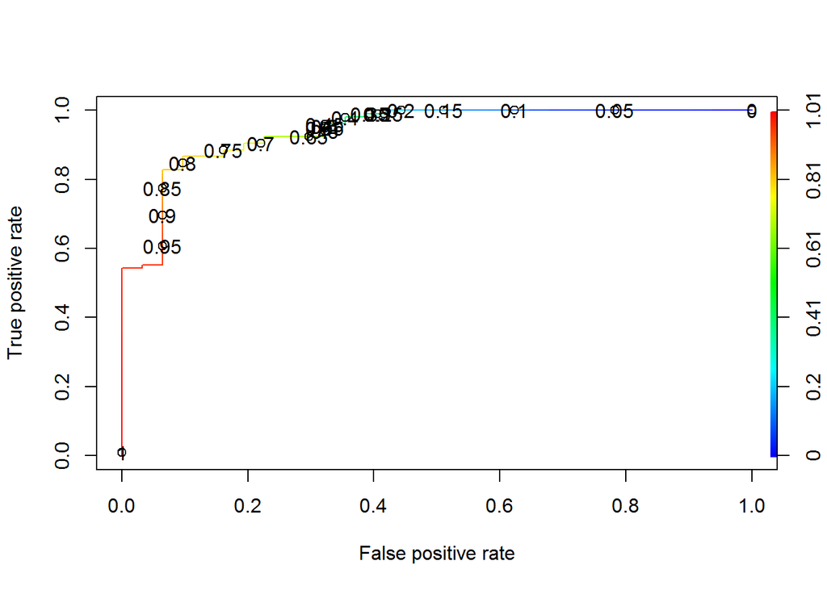

```r
plot(perf, col=rainbow(10), colorize=T, print.cutoffs.at=seq(0,1,0.05))
```

- Extract the AUC score of the ROC curve and store it in a variable named “auc”

```r
perf_auc <- performance(pred, measure="auc")

perf_auc
```

```
## An object of class "performance"
## Slot "x.name":
## [1] "None"
##
## Slot "y.name":
## [1] "Area under the ROC curve"
##
## Slot "alpha.name":
## [1] "none"
##
## Slot "x.values":
## list()
##
## Slot "y.values":
## [[1]]
## [1] 0.9403994
##
##
## Slot "alpha.values":
## list()
```